# Anova homework

Tanubrata Dey

### Tanubrata Dey

The datasets are available in R. Simply type the name of the dataset and you will be able to access it.

# CO2.

The `CO2` object contains information such as Plant ID, Origin, whether they were chilled, and how much CO2 was taken up when exposed to a specific concentration of CO2.

## 1) Linear Regression

We are going to create a regression model of the **chilled** data from **Quebec** so that we can predict the **uptake** given the **conc** of CO2.

### Subset the data

Create a subset of **CO2** with just the chilled treatment and of type Quebec. Call this **chilledQuebec**.

```r
chilledQuebec = subset(CO2, Type == "Quebec" & Treatment == "chilled")
head(chilledQuebec)
```

```
##    Plant   Type Treatment conc uptake
## 22   Qc1 Quebec   chilled   95   14.2
## 23   Qc1 Quebec   chilled  175   24.1
## 24   Qc1 Quebec   chilled  250   30.3
## 25   Qc1 Quebec   chilled  350   34.6
## 26   Qc1 Quebec   chilled  500   32.5
## 27   Qc1 Quebec   chilled  675   35.4
```

### Create a linear model

Create a linear model using the **chilledQuebec** where we are predicting uptake in response to conc of CO2. Save the model as **chilledQuebecLM**

```r
str(chilledQuebec)
```

```
## Classes 'nfnGroupedData', 'nfGroupedData', 'groupedData' and 'data.frame':   21 obs. of  5 variables:
##  $ Plant    : Ord.factor w/ 12 levels "Qn1"<"Qn2"<"Qn3"<..: 4 4 4 4 4 4 4 6 6 6 ...
##  $ Type     : Factor w/ 2 levels "Quebec","Mississippi": 1 1 1 1 1 1 1 1 1 1 ...
##  $ Treatment: Factor w/ 2 levels "nonchilled","chilled": 2 2 2 2 2 2 2 2 2 2 ...
##  $ conc     : num  95 175 250 350 500 675 1000 95 175 250 ...
##  $ uptake   : num  14.2 24.1 30.3 34.6 32.5 35.4 38.7 9.3 27.3 35 ...
```

```r
chilledQuebecLM = lm(uptake ~ conc, data = chilledQuebec)
summary(chilledQuebecLM)
```

```
##
## Call:
## lm(formula = uptake ~ conc, data = chilledQuebec)
##
## Residuals:
##      Min       1Q   Median       3Q      Max
## -14.3773  -3.7712   0.0476   4.8664  10.7414
##
## Coefficients:
##              Estimate Std. Error t value Pr(>|t|)
## (Intercept) 21.421041   2.583221   8.292 9.79e-08 ***
## conc         0.023750   0.004919   4.828 0.000117 ***
## ---
## Signif. codes:  0 '***' 0.001 '**' 0.01 '*' 0.05 '.' 0.1 ' ' 1
##
## Residual standard error: 6.631 on 19 degrees of freedom
## Multiple R-squared:  0.5509, Adjusted R-squared:  0.5273
## F-statistic: 23.31 on 1 and 19 DF,  p-value: 0.0001169
```

### plot a line

Create a line plot with conc as the x-axis and the uptake as y-axis. Plot the point AND the linear model

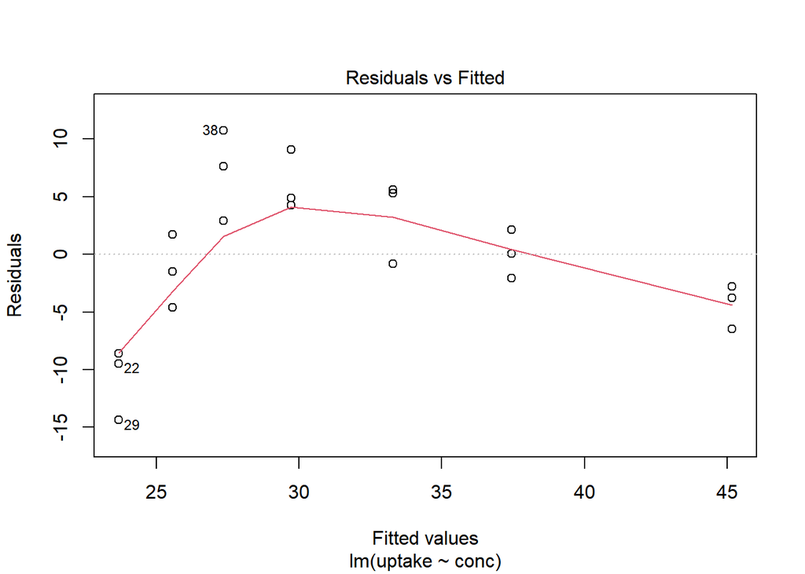

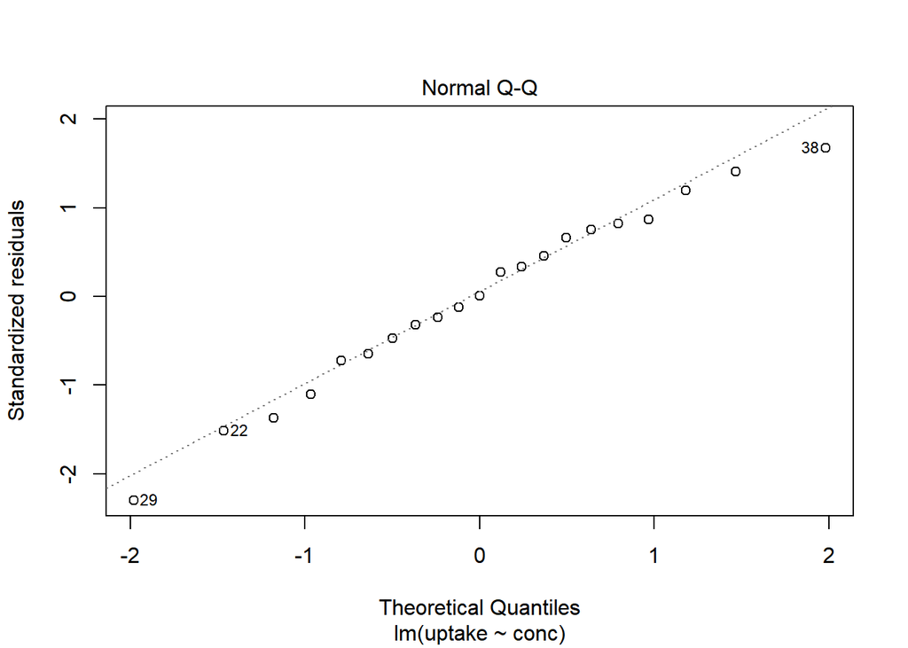

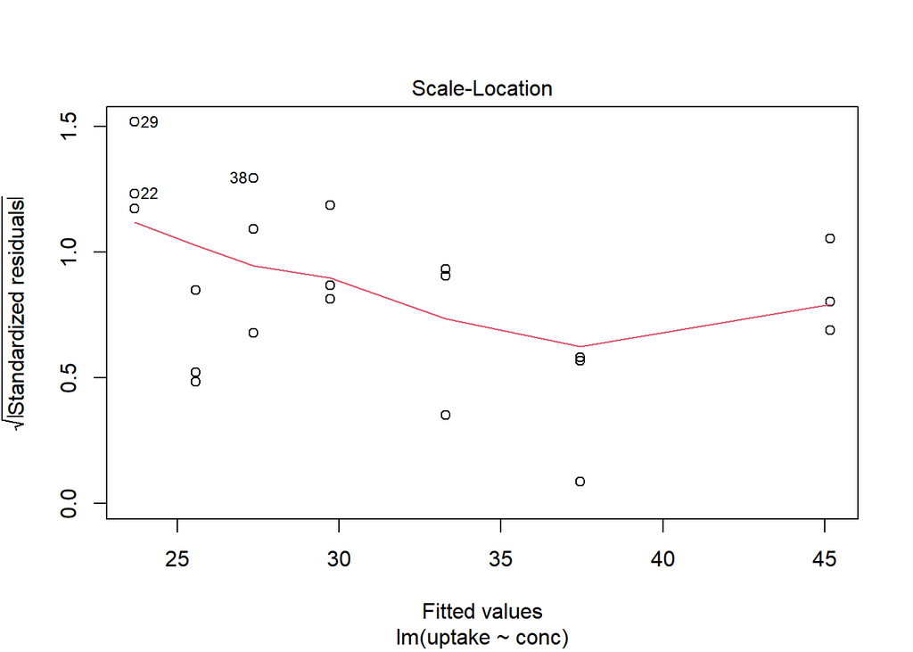

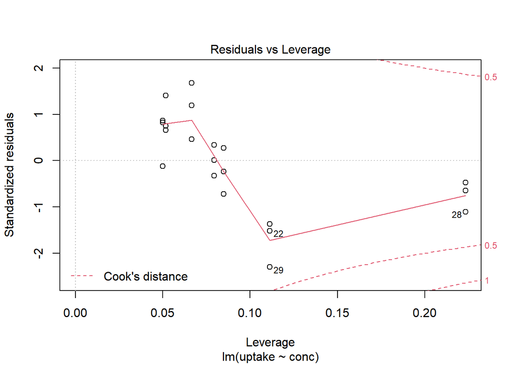

```r
#plot(chilledQuebec$conc, chilledQuebec$uptake)
#abline(lm(uptake ~ conc, data = chilledQuebec))
plot(chilledQuebecLM)
```

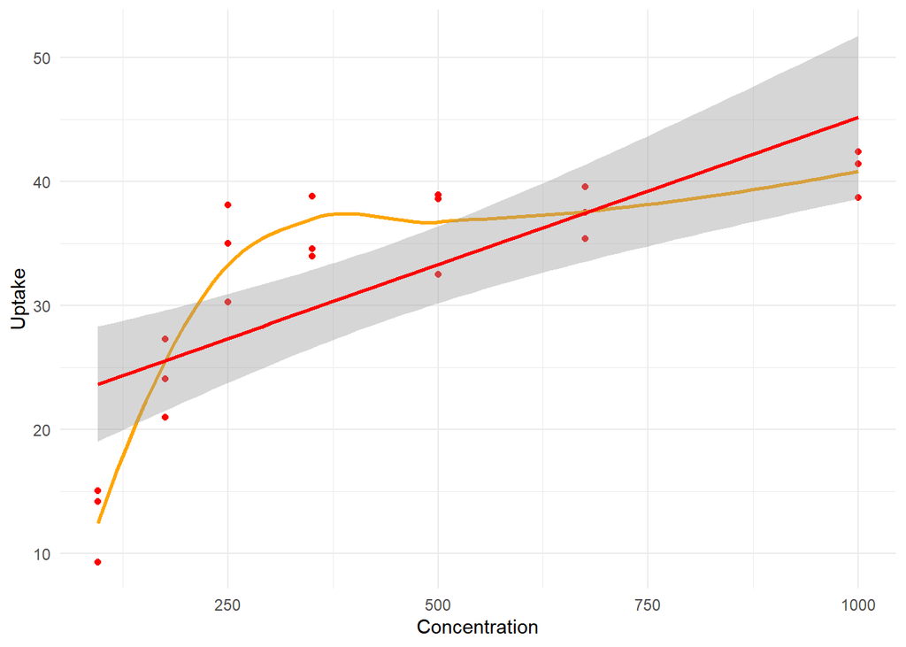

```r
library(ggplot2)
ggplot(chilledQuebec, aes(x = conc, y = uptake)) +
  labs(x = "Concentration", y = "Uptake") +
  theme_minimal() +
  geom_point(color = "red") +
  geom_smooth(method = "loess", se=FALSE, col="orange") +
  stat_smooth(method = "lm", col = "red")
```

### Interpetation

Is this a good fit? Is the relationship linear? Explain your answer.

So if you notice the above ggplot, it shows that the linear model plot in red is a straight line and the orange line in that plot is a bit curved and is more aligned with the points but the red lm line is straight but the points kind of doesn’t align much as they do in curved plot so not a good fit in red line but looks a better fit for the orange curve. Also if you check the p-value of the model, it pretty low around 0.0001 which might point the idea that the model is good. Now if you check the residual vs fitted plot above, generally if it is a straight line mostly horizontal, then it is a linear one, but in this case its curved meaning the relationship is non-linear.

### Correlation

Calculate the pearson and spearman correlation for uptake and conc from in the chilledQuebec dataset. Use the **cor.test()** function. Which of the two has a higher *rho* value? How does this align with your observation from the previous question?

```r
cor.test(x = chilledQuebec$conc, y = chilledQuebec$uptake, method = "spearman", exact = FALSE)
```

```
##
##  Spearman's rank correlation rho
##
## data:  chilledQuebec$conc and chilledQuebec$uptake
## S = 207.83, p-value = 4.183e-07
## alternative hypothesis: true rho is not equal to 0
## sample estimates:
##      rho
## 0.865043
```

```r
cor.test(x = chilledQuebec$conc, y = chilledQuebec$uptake, method = "pearson", exact = FALSE)
```

```
##
##  Pearson's product-moment correlation
##
## data:  chilledQuebec$conc and chilledQuebec$uptake
## t = 4.828, df = 19, p-value = 0.0001169
## alternative hypothesis: true correlation is not equal to 0
## 95 percent confidence interval:
##  0.4569845 0.8890613
## sample estimates:
##       cor
## 0.7422454
```

So as we know Spearman correlation is used to evaluate the monotonic relationship between two variables, so the variables tend to change together, though not in a constant rate. Whereas Pearson correlation is used to evaluate linear relationship between two variables meaning a change in one variable is associated with a proportional change in the other variable. So based on the rho value, spearman value is higher than the pearson because our data is not linear as we saw in the first question, so this could be the reason.

## 2) ANOVA

### Subset the data

Generally at concentration level 1000, the plant has taken up as much as it can so for this part we will only be interested in the amount of uptake at concentration level 1000.

Create a new dataframe called `CO2_1000` containing only the rows where concentration equals to 1000.

```r
CO2_1000 = subset(CO2, conc == 1000)
head(CO2_1000)
```

```
## Grouped Data: uptake ~ conc | Plant
##    Plant   Type  Treatment conc uptake
## 7    Qn1 Quebec nonchilled 1000   39.7
## 14   Qn2 Quebec nonchilled 1000   44.3
## 21   Qn3 Quebec nonchilled 1000   45.5
## 28   Qc1 Quebec    chilled 1000   38.7
## 35   Qc2 Quebec    chilled 1000   42.4
## 42   Qc3 Quebec    chilled 1000   41.4
```

### Perform Anova

Assuming that the data is from a normal distribution, use BOTH, the lm() and aov() functions, on the **CO2_1000** data to determine whether origin (the column `Type`), `Treatment` (chilled or non-chilled), or their `interaction` influences the amount of CO2 uptake by the plant.

```
boxplot(uptake ~ Type + Treatment, data = CO2_1000)
```

### TYPE

```r
CO2_1000_lm_type = lm(uptake ~ Type, data = CO2_1000)
summary(CO2_1000_lm_type)
```

```
##
## Call:
## lm(formula = uptake ~ Type, data = CO2_1000)
##
## Residuals:
##     Min      1Q  Median      3Q     Max
## -10.767  -3.275  -0.100   2.850  10.333
##
## Coefficients:
##                 Estimate Std. Error t value Pr(>|t|)
## (Intercept)       42.000      2.389  17.582 7.54e-09 ***
## TypeMississippi  -16.833      3.378  -4.983 0.000551 ***
## ---
## Signif. codes:  0 '***' 0.001 '**' 0.01 '*' 0.05 '.' 0.1 ' ' 1
##
## Residual standard error: 5.851 on 10 degrees of freedom
## Multiple R-squared:  0.7129, Adjusted R-squared:  0.6842
## F-statistic: 24.83 on 1 and 10 DF,  p-value: 0.0005512
```

```r
CO2_1000_aov_type = aov(uptake ~ Type, data = CO2_1000)
summary(CO2_1000_aov_type)
```

```
##             Df Sum Sq Mean Sq F value   Pr(>F)
## Type         1  850.1   850.1   24.83 0.000551 ***
## Residuals   10  342.4    34.2
## ---
## Signif. codes:  0 '***' 0.001 '**' 0.01 '*' 0.05 '.' 0.1 ' ' 1
```

### Treatment

```r
CO2_1000_lm_treat = lm(uptake ~ Treatment, data = CO2_1000)
summary(CO2_1000_lm_treat)
```

```
##
## Call:
## lm(formula = uptake ~ Treatment, data = CO2_1000)
##
## Residuals:
##      Min       1Q   Median       3Q      Max
## -15.3833  -8.3083   0.2167   8.3167  12.6167
##
## Coefficients:
##                  Estimate Std. Error t value Pr(>|t|)
## (Intercept)        37.383      4.121   9.070 3.86e-06 ***
## Treatmentchilled   -7.600      5.829  -1.304    0.221
## ---
## Signif. codes:  0 '***' 0.001 '**' 0.01 '*' 0.05 '.' 0.1 ' ' 1
##
## Residual standard error: 10.1 on 10 degrees of freedom
## Multiple R-squared:  0.1453, Adjusted R-squared:  0.05984
## F-statistic:   1.7 on 1 and 10 DF,  p-value: 0.2215
```

```r
CO2_1000_aov_treat = aov(uptake ~ Treatment, data = CO2_1000)
summary(CO2_1000_aov_treat)
```

```
##             Df Sum Sq Mean Sq F value Pr(>F)
## Treatment    1  173.3   173.3     1.7  0.221
## Residuals   10 1019.2   101.9
```

### Type + Treatment

```r
CO2_1000_lm = lm(uptake ~ Type * Treatment, data = CO2_1000)
summary(CO2_1000_lm)
```

```
##
## Call:
## lm(formula = uptake ~ Type * Treatment, data = CO2_1000)
##
## Residuals:
##    Min     1Q Median     3Q    Max
## -4.333 -2.467  0.850  1.758  3.900
##
## Coefficients:
##                                  Estimate Std. Error t value Pr(>|t|)
## (Intercept)                        43.167      1.892  22.817 1.44e-08 ***
## TypeMississippi                   -11.567      2.676  -4.323  0.00254 **
## Treatmentchilled                   -2.333      2.676  -0.872  0.40856
## TypeMississippi:Treatmentchilled  -10.533      3.784  -2.784  0.02378 *
## ---
## Signif. codes:  0 '***' 0.001 '**' 0.01 '*' 0.05 '.' 0.1 ' ' 1
##
## Residual standard error: 3.277 on 8 degrees of freedom
## Multiple R-squared:  0.928,  Adjusted R-squared:  0.901
## F-statistic: 34.35 on 3 and 8 DF,  p-value: 6.432e-05
```

```r
CO2_1000_aov = aov(uptake ~ Type * Treatment, data = CO2_1000)
summary(CO2_1000_aov)
```

```
##                Df Sum Sq Mean Sq F value   Pr(>F)
## Type            1  850.1   850.1   79.17 2.02e-05 ***
## Treatment       1  173.3   173.3   16.14  0.00386 **
## Type:Treatment  1   83.2    83.2    7.75  0.02378 *
## Residuals       8   85.9    10.7
## ---
## Signif. codes:  0 '***' 0.001 '**' 0.01 '*' 0.05 '.' 0.1 ' ' 1
```

### Interpratation

Explain the results from both functions and explain why they are different.

[output not shown]

### Boxplot

Create a boxplot showing the 4 different in the **CO2_1000** data. combinations:

**Quebec-chilled, Quebec-nonchilled, Mississippi-chilled, Mississippi-nonchilled**

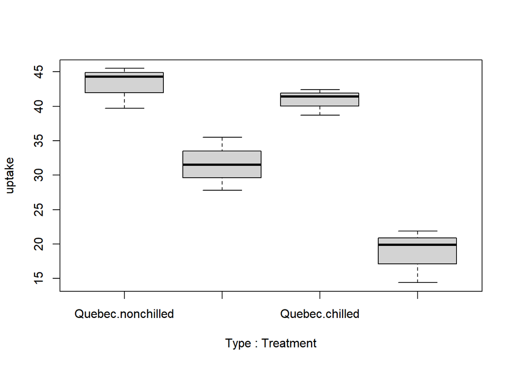

```r
boxplot(uptake ~ Type * Treatment, data = CO2_1000)
```

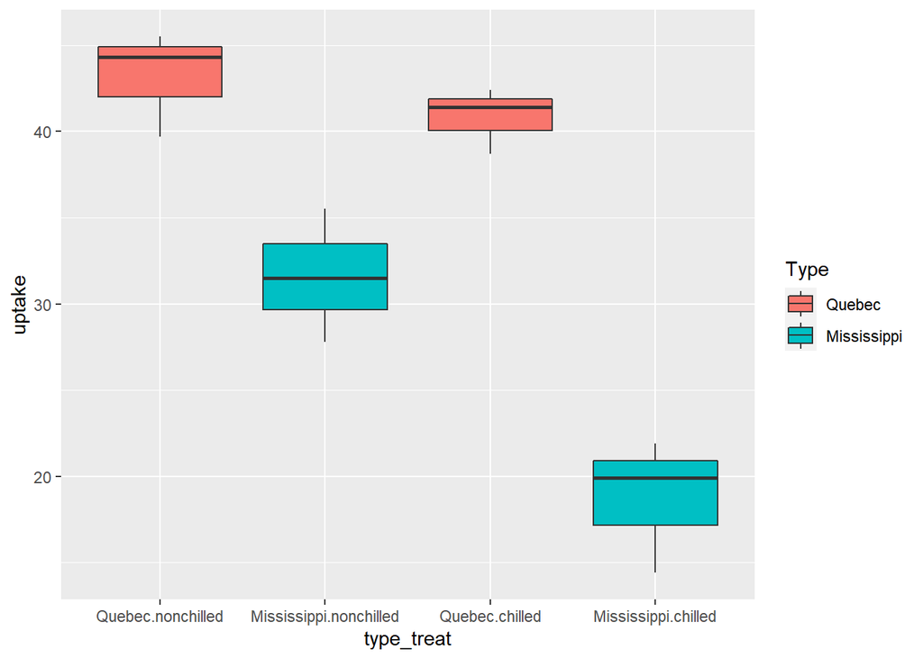

```r
library(ggplot2)
CO2_1000$type_treat <- interaction(CO2_1000$Type, CO2_1000$Treatment)
ggplot(aes(y = uptake, x = type_treat, fill = Type), data = CO2_1000) + geom_boxplot()
```

### Visual Confirmation

Based on the plot, do the results from the significant test in part 2 make sense? Explain.

Comprehending the boxplot above, if you notice Type Quebec with non-chilled Treatment has higher uptake means compared to Type Quebec with chilled Treatment and also type Mississippi with non-chilled Treatment has higher uptake means compared to Type Mississippi with chilled Treatment. Though Quebec-nonchilled has higher uptake than Mississippi-nonchilled but if you notice the chilled treatment is decreasing the uptake. From part 2 the p-value gives us an idea that the data is significant and yes the results make sense.

```r
#
```